# 03.2: GPA with Semilandmarks

Antigoni Kaliontzopoulou, Dean Adams & Michael Collyer

02 June, 2026

## **Content Description**

Yesterday we performed Generalized Procrustes Analysis (GPA) on sets of ‘fixed’ landmarks. Today we learned that the GPA algorithm may be extended to incorporate sliding semilandmarks on curves and surfaces. Let’s see how one may performs GPA on points, curves, and surfaces in `geomorph`, using the function `gpagen`:

## **Example 1: fixed points only**

```r
library(geomorph)
data(plethodon)
pleth.gpa <- gpagen(plethodon$land, print.progress = F)
summary(pleth.gpa)
```

```
##
## Call:
## gpagen(A = plethodon$land, print.progress = F)
##
##
##
## Generalized Procrustes Analysis
## with Partial Procrustes Superimposition
##
## 12 fixed landmarks
## 0 semilandmarks (sliders)
## 2-dimensional landmarks
## 2 GPA iterations to converge
##
##
## Consensus (mean) Configuration
##
##              X            Y
## 1   0.15233235 -0.025236647
## 2   0.19328979 -0.095041344
## 3  -0.03370053 -0.006929874
## 4  -0.28182427 -0.089370882
## 5  -0.31072667 -0.057833070
## 6  -0.32600020 -0.032082160
## 7  -0.31757270  0.040056685
## 8  -0.18824427  0.100347118
## 9   0.02159274  0.098853343
## 10  0.18946790  0.074940119
## 11  0.35213101  0.061515271
## 12  0.54925485 -0.069218559
```

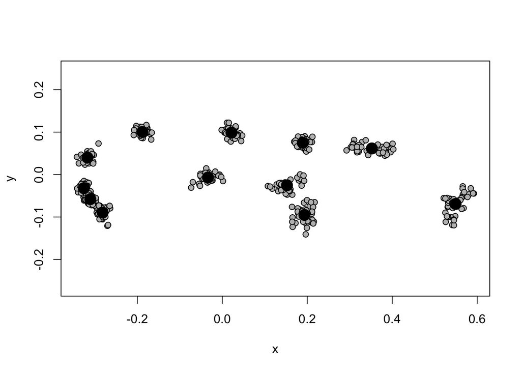

```r
plot(pleth.gpa)
```

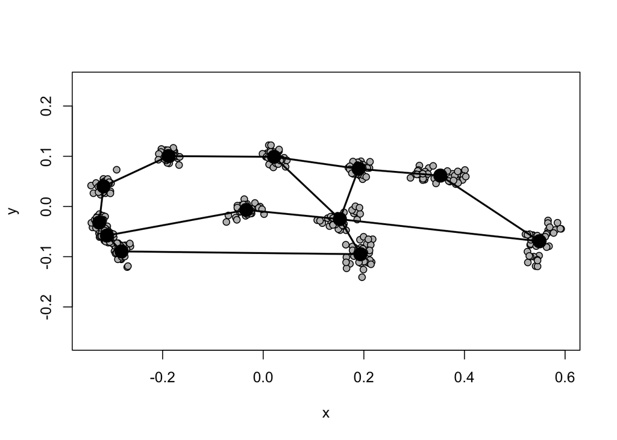

```r
plotAllSpecimens(pleth.gpa$coords, links = plethodon$links)
```

## **Example 2: Points and Semilandmarks on Curves**

Now let’s add some points on curves. To do so in `geomorph`, one must provide `gpagen` with a matrix which specifies which landmarks should be treated as sliding semilandmarks. This information is found in the ‘sliders’ matrix, which is a $\small{m \times 3}$ matrix for $\small{m}$ sliding semilandmarks. The middle column specifies which landmarks are sliding semilandmarks: the $\small{1}^{st}$ and $\small{3}^{rd}$ columns specify which landmarks ‘flank’ the semilandmark, and define the directions for the sliding. One sees an example below, in `hummingbird`, `curvepts` object:

```r
data(hummingbirds)
hummingbirds$curvepts
```

```
##       before slide after
##  [1,]      1    11    12
##  [2,]     11    12    13
##  [3,]     13    14    15
##  [4,]      7    15    14
##  [5,]     12    13    14
##  [6,]      1    16    17
##  [7,]     16    17    18
##  [8,]     17    18    19
##  [9,]     18    19    20
## [10,]     10    20    19
## [11,]      2    21    22
## [12,]     21    22    23
## [13,]     22    23    24
## [14,]     23    24    25
## [15,]      8    25    24
```

### Using Bending Energy for Sliding

Recall that there are two ways to perform the sliding: optimizing by Bending Energy or optimizing by Procrustes Distance (*see Semilandmark Lecture*). Using bending energy is more computationally-expensive, but is the preferred approach, as it is akin to a weighted regression where one weights the sliding inversely by spatial scale. This is accomplished in `geomorph` as follows:

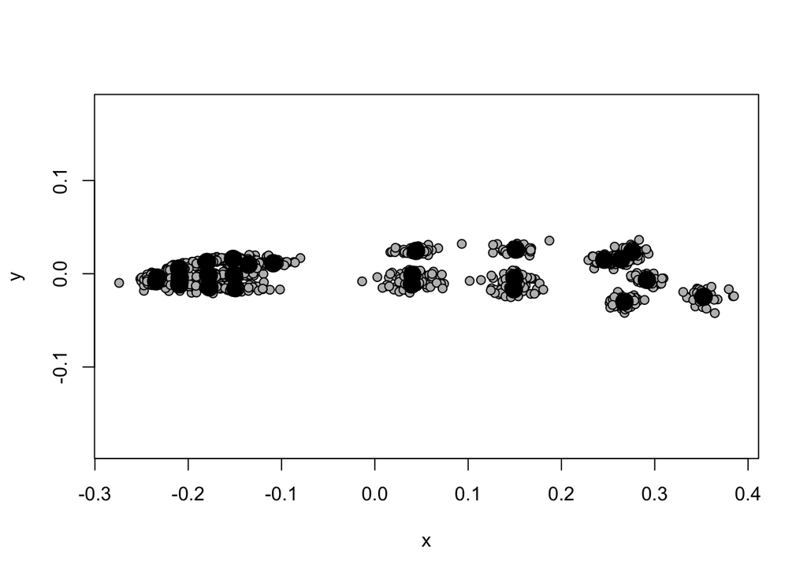

```r
gpa.BE <- gpagen(hummingbirds$land, curves=hummingbirds$curvepts, ProcD=FALSE, print.progress = F)
plot(gpa.BE)
```